# Reducción de la factorialidad. Análisis de Componentes Principales.

Ricardo Alberich, Juan Gabriel Gomila y Arnau Mir

## Introducción

- El problema central del análisis de datos es la reducción de la dimensionalidad.
- Es decir, si es posible describir con precisión los valores de las $p$ variables por un pequeño subconjunto $r<p$ de ellas con una pérdida mínima de información.
- Éste es el objetivo del análisis de componentes principales: dadas $n$ observaciones de $p$ variables, se analiza si es posible representar esta información con menos variables.
- Para alcanzar dicho objetivo, vamos a realizar un ajuste ortogonal por mínimos cuadrados.

# Análisis de Componentes Principales

## Introducción: Matriz (tabla) de datos.

*Tanto los individuos como las variables suplementarias ayudan a interpretar la variabilidad de los datos.

## Objetivos del análisis

*Reducción de la dimensionalidad (factorialidad).

## Análisis Factorial

*Algunos autores consideran el ACPcomo una parte del Análisis Factorial* En las técnicas deAF se postula que la variabilidadtotal se puede explicar mediante distintos tipos de factores:

- factores comunes subyacentes ($F_i$).
- factores específicos de las variables ($E_i$).
- fluctuaciones aleatorias ($A_i$).

$$X_1=\alpha_{1 1} F_1+ \alpha_{1 2} F_2+\cdots +\alpha_{1 k} F_k+ E_1+ A_1$$
$$X_2=\alpha_{2 1} F_1+ \alpha_{2 2} F_2+\cdots +\alpha_{2 k} F_k+ E_2+ A_2$$
$$\cdots\cdots\cdots\cdots\cdots\cdots\cdots\cdots\cdots\cdots\cdots\cdots$$
$$X_p=\alpha_{p 1} F_1+ \alpha_{p 2} F_2+\cdots +\alpha_{p k} F_k+ E_p+ A_p$$

## Análisis Factorial

*Podríamos decir que en un Análisis Factorial se fija a priori la cantidad de varianza de cada variableque debe quedar interpretada por los factores comunes.* Este valor recibe el nombre de comunalidad y se suele representarcomo $h_i^2$.

Así tenemos

*$h_i^2$ comunalidad de la variable $X_i$, es la varianza explicada por $F_1,F_2,\ldots F_k.$* $s_i^2-h_i^2$ es la varianza de lavariable $X_i$ que se queda en los factores específicos y aleatorios.

Var. observada = Var. común + Var. específica y aleat..

# El problema de los Componentes Principales

## El problema de los Componentes Principales

$$X_1=\alpha_{1 1} CP_1+ \alpha_{1 2} CP_2+\cdots +\alpha_{1 p} CP_p$$
$$X_2=\alpha_{2 1} CP_1+ \alpha_{2 2} CP_2+\cdots +\alpha_{2 p} CP_p$$
$$\cdots\cdots\cdots\cdots\cdots\cdots\cdots\cdots\cdots\cdots\cdots\cdots$$
$$X_p=\alpha_{p 1} CP_1+ \alpha_{p 2} CP_2+\cdots +\alpha_{p p} CP_p$$

Se trata de encontrar unas nuevas variables $CP_1,\ldots CP_p$, a las que llamaremos componentes principales, de forma que:

## El problema de los Componentes Principales

*Se cumplan las condiciones anteriores.* El origen de las variables esté situado en el vector de medias o centro de gravedad de las observaciones. *Sean incorreladas entre si $Cor(CP_i,CP_j)=0$ para $i\not= j, i,j =1,\ldots,p$.* $Var(CP_1)\geq Var(CP_2)\geq\cdots\geq Var(CP_p)$ y hagan máximas estas varianzas. *Se conserva la varianza total (inercia) de la nube de puntos.

# Tipos de A.C.P.

## Tipos de A.C.P:

*Sobre los datos centrados: a cada variable se le resta su media $x_i-\overline{x}_i$.* Sobre los datos tipificados $\frac{x_{i}-\overline{x}_i}{s_i}$. *En el primer caso las variables centradas tienen media cero y la misma varianza que las variables originales: se le suele llamar ACP de covarianzas.* En el segundo caso las variables tipificadas tienen media cero y varianza 1: se le suele llamar ACP de correlaciones o normado.

Recordemos que dada una matriz de datos $\mathbf{X}$ ($n\times p$ es decirde $n$ individuos y $p$ variables) representábamos por $\tilde{\mathbf{X}}$ la matriz de datos centrada. Entonces:

*La matriz de covarianzas de $\mathbf{X}$ viene dada por

$$\mathbf{S}=1/n \tilde{\mathbf{X}}^\top \tilde{\mathbf{X}}$$

*Si llamamos $\mathbf{Z}$ a la tabla de los datos tipificadosla matriz de correlaciones viene dada por

$$\mathbf{R}=1/n \mathbf{Z}^\top \mathbf{Z}$$

*Los componentes principalesvienen determinadas porlos vectores propios ortonormales (ordenados de mayor a menor valor propio) de la matriz de covarianzas (para datos centrados) y de la matriz de correlaciones (para los datos tipificados).* Así en el ACP de covarianzas cada variable interviene con su propia varianza mientras que el ACP de correlaciones todas las variables tienen varianza 1.

# ACP covarianzas:

## ACP covarianzas:

*Sea $\mathbf{S}$ la matriz de covarianzas de orden $p$. Calculamos sus valores propios

$$\lambda_1\geq \lambda_2\geq\ldots\geq\lambda_p$$

y los correspondientes vectores propios ortonormales (perpendiculares y de norma 1)

$$\mathbf{u}_1,\mathbf{u}_2,\ldots,\mathbf{u}_p$$

*Las direcciones de los componentes principales quedan determinadas por su respectivo vector.

- $$\mathbf{CP}= \tilde{\mathbf{X}} \mathbf{u},$$
  donde $\mathbf{u}$ es la matriz de los vectores propios.

## Ejemplo

Vamos a realizar un ACP sobre el ejemplo de la estatura de un niño recién nacido visto en el tema anterior de regresión.

## Ejemplo

Donde:

*$x_1:$ edad en días* $x_2:$ estatura al nacer en cm. * $x_3:$ peso en Kg. al nacer * $x_4:$ aumento en tanto por ciento de su peso con respecto de su peso al nacer. *El sexo es una variable de perfil que intentaremos explicar con nuestro análisis de componentes principales.

## Código para la carga de datos

```r
n = 9
p = 4
X = matrix(c(78,48.2,2.75,29.5,69,45.5,2.15,26.3,
77,46.3,4.41,32.2, 88,49,5.52,36.5, 67,43,3.21,27.2,
80,48,4.32,27.7, 74,48,2.31,28.3, 94,53,4.3,30.3,
102,58,3.71,28.7),nrow=n,byrow=T)
Datos= as.data.frame(X)
names(Datos) = paste("x",c(1:p),sep="")
Sexo = as.factor(c("Niña","Niña","Niña","Niño",
"Niña","Niña","Niña","Niño","Niño"))
Datos$Sexo=Sexo
```

## Código diagrama matricial

El siguiente código dibuja un diagrama matricial de las variables.

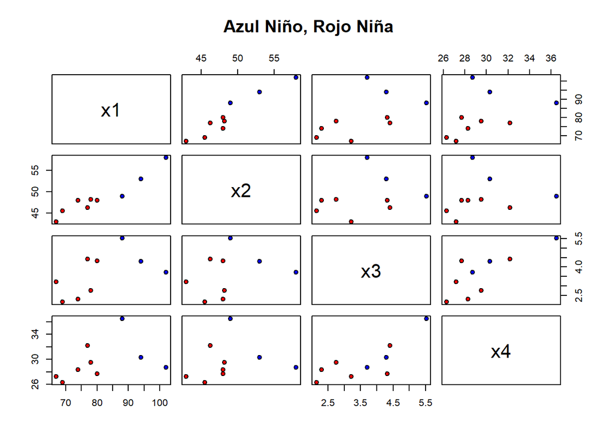

```r
pairs(Datos[,1:4],pch=21,
bg = c("red", "blue")[unclass(Datos$Sexo)],
main="Diagrama matricial de las variables.
\n Azul Niño, Rojo Niña")
legend(15,-4,legend=levels(Datos$Sexo),pch=21,
pt.bg=c("red", "blue"),title="Sexo")
```

En lo que sigue todos los datos se redondean al tercer decimal.

$$\tilde{\mathbf{X}}=
\left(
\begin{array}{rrrr}
-3.000 & -0.578 & -0.881 & -0.133 \\
-12.000 & -3.278 & -1.481 & -3.333 \\
-4.000 & -2.478 & 0.779 & 2.567 \\
7.000 & 0.222 & 1.889 & 6.867 \\
-14.000 & -5.778 & -0.421 & -2.433 \\
-1.000 & -0.778 & 0.689 & -1.933 \\
-7.000 & -0.778 & -1.321 & -1.333 \\
13.000 & 4.222 & 0.669 & 0.667 \\
21.000 & 9.222 & 0.079 & -0.933
\end{array}
\right)$$

## Ejemplo

*La matriz de covarianzas de los datos anteriores es:
$$\mathbf{S}=
\left(
\begin{array}{rrrr}
119.333 & 43.133 & 6.148 & 12.511 \\
43.133 & 17.193 & 1.148 & 1.886 \\
6.148 & 1.148 & 1.111 & 2.428 \\
12.511 & 1.886 & 2.428 & 8.624
\end{array}
\right)$$

*Los valores propios son: $136.615,\quad 8.861,\quad 0.738,\quad 0.047.$* Los vectores propios ortonormales correspondientes a los valores propios, son las columnas de la siguiente matriz:
$$\left(
\begin{array}{rrrr}
0.934 & -0.022 & 0.256 & 0.247 \\
0.339 & 0.354 & -0.661 & -0.568 \\
0.047 & -0.248 & 0.566 & -0.785 \\
0.097 & -0.902 & -0.421 & -0.013
\end{array}
\right)$$

## Ejemplo

*Las expresiones de las variables nuevas $CP_i$ en función de las antiguas, notemos que se calculan sobre los datos centrados, son:
$$\begin{array}{rl}
CP_1 = & 0.934\cdot \tilde{X}_1 + 0.339\cdot \tilde{X}_2 + 0.047\cdot
\tilde{X}_3\\ & + 0.097 \cdot \tilde{X}_4, \\
CP_2 = & -0.022\cdot \tilde{X}_1 +0.354\cdot \tilde{X}_2 -0.248 \cdot
\tilde{X}_3 \\ & -0.902 \cdot \tilde{X}_4, \\
CP_3 = & 0.256\cdot \tilde{X}_1 -0.661 \cdot \tilde{X}_2 +0.566\cdot \tilde{X}_3
\\ &-0.421\cdot \tilde{X}_4, \\
CP_4 = & 0.247 \cdot \tilde{X}_1 - 0.568\cdot \tilde{X}_2 - 0.785\cdot
\tilde{X}_3 \\ & - 0.013 \cdot \tilde{X}_4.
\end{array}$$

## Ejemplo

*La nueva matriz de datos respecto de las nuevas variables será:
$$\mathbf{CP}= \tilde{\mathbf{X}} \mathbf{u} =
\left(
\begin{array}{rrrr}
-3.054 & 0.201 & -0.827 & 0.280 \\
-12.719 & 2.480 & -0.333 & 0.103 \\
-4.293 & -3.295 & -0.025 & -0.228 \\
7.373 & -6.736 & -0.183 & 0.029 \\
-15.299 & 0.565 & 1.029 & 0.183 \\
-1.354 & 1.319 & 1.463 & -0.321 \\
-6.997 & 1.411 & -1.460 & -0.233 \\
13.677 & 0.437 & 0.629 & 0.282 \\
22.666 & 3.618 & -0.292 & -0.095 \\
\end{array}
\right)$$

*Se puede observar que si se multiplican escalarmente dos columnas cualesquiera, es resultado es nulo. Es decir, las columnas de la nueva matriz de datos son ortogonales dos a dos.

## Ejemplo

Como podemos observar, nuestro análisis ha explicado la variable de perfil sexo ya que distingue entre niños y niñas con las dos primeras componentes.

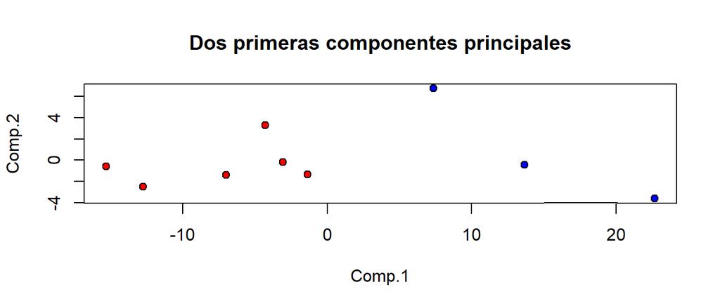

El siguiente código dibuja todos los componentes

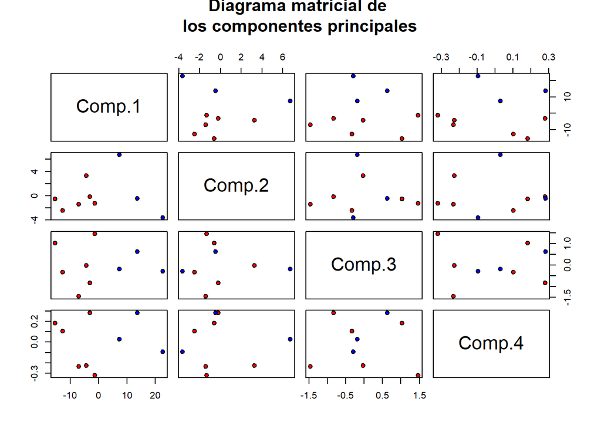

[figure not shown]

```r
pairs(solacp$scores,pch=21,
bg = c("red", "blue")[unclass(Datos$Sexo)],
main="Diagrama matricial de
los componentes principales")
```

# ACP correlaciones.

## ACP correlaciones.

Sea $\mathbf{R}$ la matriz de correlaciones de orden $p$. Calcularemos sus valores propios

$\lambda_1\geq \lambda_2\geq\ldots\geq\lambda_p$

y los correspondientes vectores propios ortonormales.

$\mathbf{u}_1,\mathbf{u}_2,\ldots,\mathbf{u}_p$

Las direcciones de los componentes principales quedan determinadas por el vector propio correspondiente.

$$\mathbf{CP}= \mathbf{Z} \mathbf{u},$$
donde $Z$ es la matriz de datos tipificados y $\mathbf{u}$ es la matriz de los vectores propios.

## Ejemplo

*Realicemos un análisis ACP de correlaciones con el ejemplo anterior.* La matriz tipificada de datos es:
$$\mathbf{Z}=
\left(
\begin{array}{rrrr}
-0.275 & -0.139 & -0.836 & -0.045 \\
-1.099 & -0.791 & -1.405 & -1.135 \\
-0.366 & -0.598 & 0.739 & 0.874 \\
0.641 & 0.054 & 1.792 & 2.338 \\
-1.282 & -1.393 & -0.400 & -0.829 \\
-0.092 & -0.188 & 0.654 & -0.658 \\
-0.641 & -0.188 & -1.254 & -0.454 \\
1.190 & 1.018 & 0.635 & 0.227 \\
1.922 & 2.224 & 0.075 & -0.318
\end{array}
\right)$$

## Ejemplo

La matriz de correlaciones $\mathbf{R}$ vale, en este caso:
$$\mathbf{R} =
\left(
\begin{array}{rrrr}
1.000 & 0.952 & 0.534 & 0.390 \\
0.952 & 1.000 & 0.263 & 0.155 \\
0.534 & 0.263 & 1.000 & 0.784 \\
0.390 & 0.155 & 0.784 & 1.000
\end{array}
\right)$$
Los valores propios de dicha matriz son:
$$2.560,\quad 1.229,\quad 0.208,\quad 0.00325.$$
*La matriz de los vectores propios es:
$$\left(
\begin{array}{rrrr}
0.573 & 0.359 & -0.038 & 0.736 \\
0.478 & 0.578 & 0.145 & -0.646 \\
0.499 & -0.459 & -0.707 & -0.201 \\
0.442 & -0.572 & 0.691 & -0.029
\end{array}
\right)$$

## Ejemplo

*Las expresiones de las variables nuevas $CP_i$ en función de las antiguas $Z_i$son:

$$\begin{array}{rl}
CP_1 = & 0.573\cdot Z_1 +0.478\cdot Z_2 +0.499\cdot Z_3\\ & +0.442 \cdot Z_4,
\\
CP_2 = & 0.359\cdot Z_1 + 0.578\cdot Z_2 -0.459 \cdot Z_3 \\ & -0.572 \cdot Z_4,
\\
CP_3 = & -0.038\cdot Z_1 +0.145 \cdot Z_2 -0.707\cdot Z_3 \\ &+0.691\cdot Z_4,
\\
CP_4 = & 0.736 \cdot Z_1 - 0.646\cdot Z_2 - 0.201\cdot Z_3 \\ & - 0.029 \cdot
Z_4.
\end{array}$$

## Ejemplo

*La nueva matriz de datos respecto de las nuevas variables será:

$$\mathbf{CP} = \mathbf{Z} \mathbf{u} =
\begin{pmatrix}
-0.661 & 0.231 & 0.550 & 0.057 \\
-2.209 & 0.443 & 0.137 & 0.018 \\
0.259 & -1.316 & 0.008 & -0.058 \\
2.319 & -1.899 & 0.332 & 0.008 \\
-1.965 & -0.608 & -0.444 & 0.061 \\
-0.107 & -0.065 & -0.941 & -0.058 \\
-1.282 & 0.497 & 0.570 & -0.085 \\
1.585 & 0.594 & -0.189 & 0.084 \\
2.061 & 2.122 & -0.023 & -0.027
\end{pmatrix}$$

*Se puede observar que si calculamos el productoescalar de dos columnas cualesquiera, es resultado es nulo. Es decir, las columnas de la nueva matriz de datos son ortogonales dos a dos.

# Propiedades ACP covarianzas.

## Propiedades ACP covarianzas.

Sea $\mathbf{X}$ una matriz de datos $n\times p$ y sea

$$\mathbf{S}=\begin{pmatrix}
s_1^2& s_{ 1 2}&\ldots &s_{1 p}\\
s_{2 1}& s_{2}^2&\ldots &s_{2 p}\\
\vdots & \vdots &\ddots & \vdots\\
s_{p 1}& s_{ p 2}&\ldots &s_{p}^2
\end{pmatrix}$$
su matriz de covarianzas.

Recordemos que $s_i^2$ es la varianza de la variable $\mathbf{x}_i$ y que $s_{i j}$ son las covarianzas de la variables $\mathbf{x}_i$ y $\mathbf{x}_j$.

Además la $\mbox{Varianza Total}= tr(\mathbf{S})=\sum_{i=1}^p s_i^2$

## Propiedades ACP covarianzas.

- $Var(\mathbf{CP}_i)= \lambda_i$. La varianza de cada componente principal es su valor propio.
- $\sum_{i=1}^n Var(\mathbf{CP}_i)=\sum_{i=1}^n \lambda_i=tr(\mathbf{S})=\sum_{i=1}^n s_i^2$. Por lo tanto los componentes principales reproducen la varianza total
- Los componentes principales tienen correlación cero entre sí (son *incorrelados*) por lo tanto su matriz de covarianzas es
  $$\mathbf{S}_{CP}=\left(\begin{array}{cccc}
  \lambda_1& 0 &\ldots &0\\
  0& \lambda_{2}&\ldots & 0\\
  \vdots & \vdots & & \vdots\\
  0 & 0&\ldots &\lambda_{p}
  \end{array}
  \right)$$

## Propiedades ACP covarianzas.

- $\det(\mathbf{S}_{CP})=\prod_{i=1}^n \lambda_i =\det(\mathbf{S})$. Luego los componentes principales conservan la varianza generalizada.
- La proporción de varianza explicada por la componente $j$-ésima es
  $$\frac{\lambda_j}{\sum_{i=1}^n \lambda_i}.$$

Además al ser* incorrelados* la proporción de varianza explicada por los $k$ primeros componentes es
$$\frac{\sum_{i=1}^k
\lambda_i}{\sum_{i=1}^n \lambda_i}.$$

- $\mbox{Cov}(\tilde{\mathbf{X}}_i, \mathbf{CP}_j)=\lambda_j u_{j i}$; $corr(\tilde{\mathbf{X}}_i, \mathbf{CP}_j)=\frac{\sqrt{\lambda_j} u_{j i}}{s_i}$ donde $u_{j i}$ es la $i$-ésima componente del vector propio $\mathbf{u}_j$.

## Ejemplo

Vamos a comprobar las propiedades anteriores con nuestro ejemplo. Recordemos las matrices de datos de las variables originales $\mathbf{X}$ (centradas) y de las variables en componentes principales $\mathbf{CP}$:
$${\tiny
\begin{array}{rl}
\tilde{\mathbf{X}} =&
\left(
\begin{array}{rrrr}
-3.000 & -0.578 & -0.881 & -0.133 \\
-12.000 & -3.278 & -1.481 & -3.333 \\
-4.000 & -2.478 & 0.779 & 2.567 \\
7.000 & 0.222 & 1.889 & 6.867 \\
-14.000 & -5.778 & -0.421 & -2.433 \\
-1.000 & -0.778 & 0.689 & -1.933 \\
-7.000 & -0.778 & -1.321 & -1.333 \\
13.000 & 4.222 & 0.669 & 0.667 \\
21.000 & 9.222 & 0.079 & -0.933
\end{array}
\right) ,
\\ &\\
\mathbf{CP}= &
\left(
\begin{array}{rrrr}
-3.054 & 0.201 & -0.827 & 0.280 \\
-12.719 & 2.480 & -0.333 & 0.103 \\
-4.293 & -3.295 & -0.025 & -0.228 \\
7.373 & -6.736 & -0.183 & 0.029 \\
-15.299 & 0.565 & 1.029 & 0.183 \\
-1.354 & 1.319 & 1.463 & -0.321 \\
-6.997 & 1.411 & -1.460 & -0.233 \\
13.677 & 0.437 & 0.629 & 0.282 \\
22.666 & 3.618 & -0.292 & -0.095
\end{array}
\right).
\end{array}}$$

## Ejemplo

- La matriz de los vectores propios de la matriz $\mathbf{S}$ era:
  $${\tiny
  \left(
  \begin{array}{rrrr}
  0.934 & -0.022 & 0.256 & 0.247 \\
  0.339 & 0.354 & -0.661 & -0.568 \\
  0.047 & -0.248 & 0.566 & -0.785 \\
  0.097 & -0.902 & -0.421 & -0.013
  \end{array}\right).}$$
  Las varianzas de las variables $CP$ son las siguientes:
  $$\begin{array}{llcll}
  \mbox{Var}(\mathbf{CP}_1) & =136.615,\ & \mbox{Var}(\mathbf{CP}_2) & =8.861,\\
  \mbox{Var}(\mathbf{CP}_3) & =0.738,\ &\mbox{Var}(\mathbf{CP}_4) & =0.0468,
  \end{array}$$
  valores que corresponden a los valores propios de la matriz de covarianzas~$\mathbf{S}$. La traza de la matriz $\mathbf{S}$ vale: $tr(\mathbf{S})=146.261$. Si sumamos los 4 valores propios, su valor coincide con el valor anterior: $\lambda_1 + \lambda_2+ \lambda_3 + \lambda_4 = 146.261$.

## Ejemplo

- La matriz de covarianzas de las variables $\mathbf{CP}$ vale:
  $$cov(\mathbf{CP})=
  \left(
  \begin{array}{rrrr}
  136.615 & 0.000 & 0.000 & 0.000 \\
  0.000 & 8.861 & 0.000 & 0.000 \\
  0.000 & 0.000 & 0.738 & 0.000 \\
  0.000 & 0.000 & 0.000 & 0.047
  \end{array}
  \right)$$
  Podemos observar que es una matriz diagonal con los valores propios de la matriz $\mathbf{S}$ en la diagonal. *El determinante de las matrices de covarianzas de $\tilde{\mathbf{X}}$ y $\mathbf{CP}$ vale $41.785$, valor que coincide con el producto de los valores propios de la matriz $\mathbf{S}$:
  $$136.615\cdot 8.861\cdot 0.738\cdot 0.0468 = 41.785.$$

## Ejemplo

*La matriz de covarianzas entre las variables $\tilde{\mathbf{X}}$ y $\mathbf{CP}$ vale:
$$cov(\tilde{\mathbf{X}},\mathbf{CP})=
\left(
\begin{array}{rrrr}
127.653 & -0.198 & 0.189 & 0.012 \\
46.377 & 3.138 & -0.488 & -0.027 \\
6.422 & -2.195 & 0.417 & -0.037 \\
13.283 & -7.989 & -0.311 & -0.001
\end{array}
\right)$$

Recuperemos la matriz de vectores propios de la matriz$\mathbf{S}$:

$${\tiny \left(
\begin{array}{rrrr}
0.934 & -0.022 & 0.256 & 0.247 \\
0.339 & 0.354 & -0.661 & -0.568 \\
0.047 & -0.248 & 0.566 & -0.785 \\
0.097 & -0.902 & -0.421 & -0.013
\end{array}
\right)
.}$$

## Ejemplo

Si multiplicamos la primera columna de la matriz anterior

$$\begin{pmatrix}
0.934\\ 0.339\\ 0.047\\ 0.097
\end{pmatrix}$$

por el valor propio $136.615$ de la matriz $\mathbf{S}$ obtenemos la primera columna de la matriz

$\mbox{Cov}(\tilde{\mathbf{X}},\mathbf{CP})$:

$$136.615\cdot \begin{pmatrix}0.934\\ 0.339\\ 0.047\\ 0.097\end{pmatrix}=
\begin{pmatrix}
127.652 \\ 46.377 \\ 6.422 \\ 13.283
\end{pmatrix}$$
*En general, podemos escribir:

$$\mathbf{u}\cdot \mbox{diag}(\lambda) = \mbox{Cov}(\tilde{\mathbf{X}},\mathbf{CP}),$$

donde $\mathbf{u}$ es la matriz formada por los vectores propios de la matriz $\mathbf{S}$ y $\mbox{diag}(\lambda)$ es una matriz diagonal con los valores propios de la matriz $\mathbf{S}$ en la diagonal.

## Propiedades ACP covarianzas.

- La primera componente principal es la recta que conserva mayor inerciade la nube de puntos.
- Las dos primeras componentes principales forman el plano que conserva mayor inerciade la nube de puntos.
- Lo mismo sucede con los espacios formados por las $k$ primeras componentes

# Propiedades ACP correlaciones.

## Propiedades ACP correlaciones.

Sea $\mathbf{X}$ una matriz de datos $n\times p$ y sea

$$\mathbf{R}=\left(\begin{array}{cccc}
1& r_{ 1 2}&\ldots &r_{1 p}\\
r_{2 1}& 1&\ldots &r_{2 p}\\
\vdots & \vdots & \ddots& \vdots\\
r_{p 1}& s_{ p 2}&\ldots &1
\end{array}
\right)$$
Su matriz de correlaciones. Se verifican las siguientes propiedades:

- Recordemos quela diagonal es $1$ pues es la varianza de los datos tipificados y que $r_{i j}$ son las correlaciones lineales de la variables $\mathbf{x}_i$ y $\mathbf{x}_j$.

*Además la $\mbox{Varianza Total}= tr(\mathbf{R})=p$

## Propiedades ACP correlaciones.

- $Var(\mathbf{CP}_i)= \lambda_i$. El valor propio del componente es igual a su varianza
- $\sum_{i=1}^n var(\mathbf{CP}_i)=\sum_{i=1}^n \lambda_i=tr(\mathbf{R})=p$. Por lo tanto los componentes principales reproducen la varianza total y ésta es igual al numero de variables $p$. *Los componentes principales tienen correlación cero entre sí (son* incorrelados*) por lo tanto su matriz de covarianzas ( que este caso es igual a la de correlaciones es

$$\mathbf{S}_{CP}=\left(\begin{array}{cccc}
\lambda_1& 0 &\ldots &0\\
0& \lambda_{2}&\ldots & 0\\
\vdots & \vdots &\ddots & \vdots\\
0 & 0&\ldots &\lambda_{p}
\end{array}
\right)$$

## Propiedades ACP correlaciones.

- $\det(\mathbf{S}_{CP})=\prod_{i=1}^n \lambda_i =\det(\mathbf{R})$. Luego los componentes principales conservan la varianza generalizada.
- La proporción de varianza explicada por cada componente es
  $$\frac{\lambda_i}{p}.$$

Además al ser *incorreladas* la proporción de varianza explicada por los $k$ primeros componentes es
$$\frac{\sum_{i=1}^k \lambda_i}{p}.$$

- $corr(\mathbf{Z}_i, \mathbf{CP}_j)=\sqrt{\lambda_j}\cdot u_{j i}$ donde $u_{j i}$ es la $i$-ésima componente del vector propio $\mathbf{u}_j$.

## Propiedades ACP correlaciones.

Vamos a comprobar las propiedades anteriores con nuestro ejemplo. Recordemos las matrices de datos estandarizada$\mathbf{Z}$y de las variables en componentes principales $\mathbf{CP}$:

$$\mathbf{Z}=
\begin{pmatrix}
-0.275 & -0.139 & -0.836 & -0.045 \\
-1.099 & -0.791 & -1.405 & -1.135 \\
-0.366 & -0.598 & 0.739 & 0.874 \\
0.641 & 0.054 & 1.792 & 2.338 \\
-1.282 & -1.393 & -0.400 & -0.829 \\
-0.092 & -0.188 & 0.654 & -0.658 \\
-0.641 & -0.188 & -1.254 & -0.454 \\
1.190 & 1.018 & 0.635 & 0.227 \\
1.922 & 2.224 & 0.075 & -0.318
\end{pmatrix}$$

## Ejemplo

$$\mathbf{CP}=
\begin{pmatrix}
-0.661 & 0.231 & 0.550 & 0.057 \\
-2.209 & 0.443 & 0.137 & 0.018 \\
0.259 & -1.316 & 0.008 & -0.058 \\
2.319 & -1.899 & 0.332 & 0.008 \\
-1.965 & -0.608 & -0.444 & 0.061 \\
-0.107 & -0.065 & -0.941 & -0.058 \\
-1.282 & 0.497 & 0.570 & -0.085 \\
1.585 & 0.594 & -0.189 & 0.084 \\
2.061 & 2.122 & -0.023 & -0.027
\end{pmatrix}.$$

## Ejemplo

$$\begin{array}{llcll}
\mbox{Var}(\mathbf{CP}_1) & =2.560,\ & \mbox{Var}(\mathbf{CP}_2) & =1.229,\\
\mbox{Var}(\mathbf{CP}_3) & =0.208,\ & \mbox{Var}(\mathbf{CP}_4) & =0.00325,
\end{array}$$

## Ejemplo

$$\mbox{Cov}(\mathbf{CP})= \mathbf{S}_{\mathbf{CP}} =
\begin{pmatrix}
2.560 & 0.000 & 0.000 & 0.000 \\
0.000 & 1.229 & 0.000 & 0.000 \\
0.000 & 0.000 & 0.208 & 0.000 \\
0.000 & 0.000 & 0.000 & 0.003
\end{pmatrix}$$

## Ejemplo

$$\textcolor{red}{\det(\mathbf{S}_{\mathbf{CP}})=0.00213},$$

$$\prod_{i=1}^4\lambda_i= 2.560\cdot 1.229\cdot 0.208\cdot 0.00325 = 0.00213.$$

## Ejemplo

La matriz de correlaciones entre las variables $\mathbf{Z}$ y $\mathbf{CP}$ es:

$$\mbox{Cor}(\mathbf{Z},\mathbf{CP}) =
\begin{pmatrix}
0.916 & 0.398 & -0.017 & 0.042 \\
0.764 & 0.641 & 0.066 & -0.037 \\
0.798 & -0.509 & -0.323 & -0.011 \\
0.706 & -0.634 & 0.315 & -0.002
\end{pmatrix}$$

La matriz de vectores propios de la matriz $\mathbf{ R}$ es:

$$\begin{pmatrix}
0.573 & 0.359 & -0.038 & 0.736 \\
0.478 & 0.578 & 0.145 & -0.646 \\
0.499 & -0.459 & -0.707 & -0.201 \\
0.442 & -0.572 & 0.691 & -0.029.
\end{pmatrix}$$

## Ejemplo

Si multiplicamos la primera columna de la matriz anterior

$$\begin{pmatrix}0.573 \\ 0.478\\ 0.499 \\ 0.442\end{pmatrix}$$

por la raíz cuadrada del primer valor propio de la matriz $\mathbf{R}$, $\sqrt{2.560}$, obtenemos la primera columna de la matriz

$$\mbox{Cor}(\mathbf{Z},\mathbf{CP}),$$

efectivamente

## Ejemplo

$$\sqrt{2.560}\cdot \begin{pmatrix}0.573 \\ 0.478\\ 0.499 \\ 0.442\end{pmatrix} =
\textcolor{red}{\begin{pmatrix}0.916 \\ 0.764\\ 0.798 \\ 0.706\end{pmatrix}}$$

$$Cor(\mathbf{Z},\mathbf{CP}) =
\begin{pmatrix}
\textcolor{red}{0.916} & 0.398 & -0.017 & 0.042 \\
\textcolor{red}{0.764} & 0.641 & 0.066 & -0.037 \\
\textcolor{red}{0.798} & -0.509 & -0.323 & -0.011 \\
\textcolor{red}{0.706} & -0.634 & 0.315 & -0.002
\end{pmatrix}$$

## Ejemplo

- En general, podemos escribir:

$$\mathbf{u}\cdot \mbox{diag}(\sqrt{\lambda}) = \mbox{Cor}(\mathbf{Z},\mathbf{CP}),$$

## Propiedades ACP correlaciones

- La primera componente principal es la recta que conserva mayor inerciade la nube de puntos.
- Los dos primeros componentes principales forma el plano que conserva mayor inerciade la nube de puntos.
- Lo mismo sucede con los espacios formados por los $k$ primeros componentes

# Etapas de un ACP

## Etapas de un ACP

- Determinar las variables e individuos que intervienen en el análisis, las variables de perfil y los individuos ilustrativos.
- Decidir si se realiza el análisis sobre los datos brutos (matriz de covarianzas) o sobre los datos tipificados (matriz de correlaciones):
- Cuando las variables originales $\mathbf{X}$ están medidas en distintas unidades, conviene aplicar el análisis de correlaciones. Si están en las mismas unidades, ambas alternativas son posibles.
- Si las diferencias entre las varianzas son informativas y queremos tenerlas en cuenta en el análisis, no debemos estandarizar las variables.

## Etapas de un ACP

# Retención de componentes

## Retención de componentes

Una vez realizado el ACP tengo que decidir que número de componentes se retienen. Existen diversos métodos: .Seleccionar componentes hasta cubrir una proporción determinada de varianza, como el $80\%$ o el $90\%$.

- En el ejemplo que hemos desarrollado, tenemos que con un análisis de covarianzas, si sólo elegimos la primera componente, cubrimos el $93.4\%$ de la varianza. Si elegimos, las dos primeras, cubrimos el $99.5\%$ de la varianza. Con las tres primeras, cubrimos el $99.9\%$ de la varianza.
- En cambio, con un análisis de correlaciones, con la primera componente, sólo cubrimos el $64\%$ de la varianza; con las dos primeras, el $94.7\%$ de la varianza y con las tres primeras, el $99.9\%$ de la varianza.

# Técnicas de retención de reteción de componentes

## Retención de componentes

. Se retienen todas las componentes $\mathbf{CP}_i$ que cumplan $\lambda_i\geq\overline{\lambda}=\frac{\sum_{i=1}^p \lambda_i}{p}$ En el caso del análisis de correlaciones, la condición anterior equivale a retener los componentes con valores propios mayores que~1.

- En nuestro ejemplo, para el análisis de covarianzas, tenemos que: $\overline{\lambda}=36.565$. Recordemos que los valores propios de la matriz de covarianzas $\mathbf{S}$ eran: $136.615,\ 8.861,\ 0.738,\ 0.0468$. Por tanto, tenemos que retener sólo la componente $\mathbf{CP}_1$.
- Para el análisis de correlaciones, recordemos que los valores propios de la matriz~$\mathbf{R}$ eran: $2.560,\ 1.229,\ 0.208,\ 0.00324$. En este caso, tenemos que retener los componentes $\mathbf{CP}_1$ y $\mathbf{CP}_2$.

## Gráfico de sedimentación, regla del codo

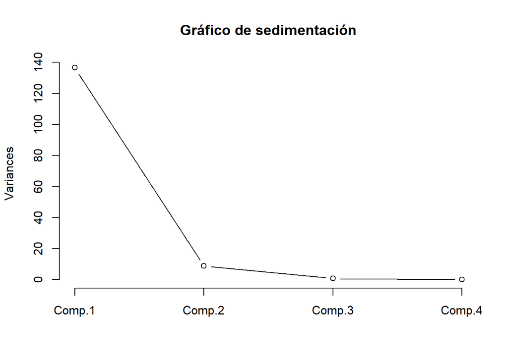

```r
screeplot(solacp,type="lines",main="Gráfico de sedimentación")
```

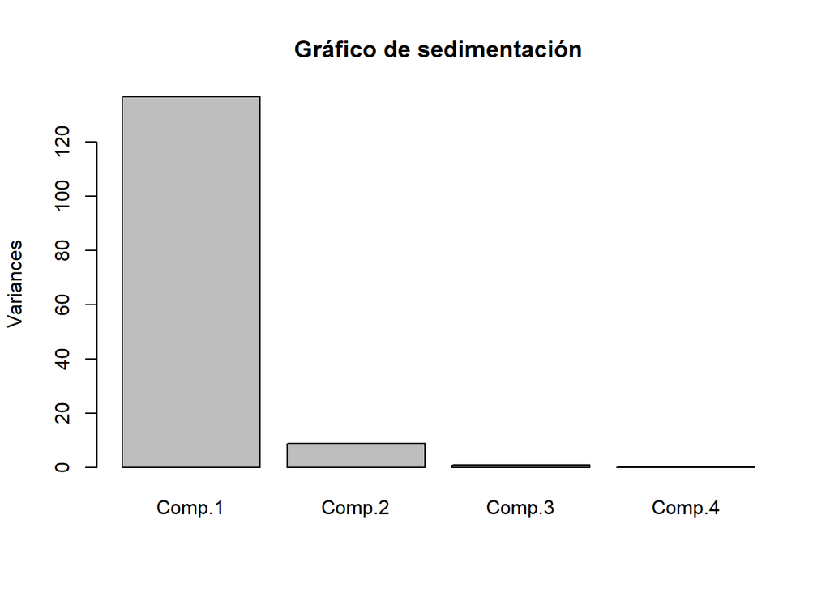

[figure not shown]

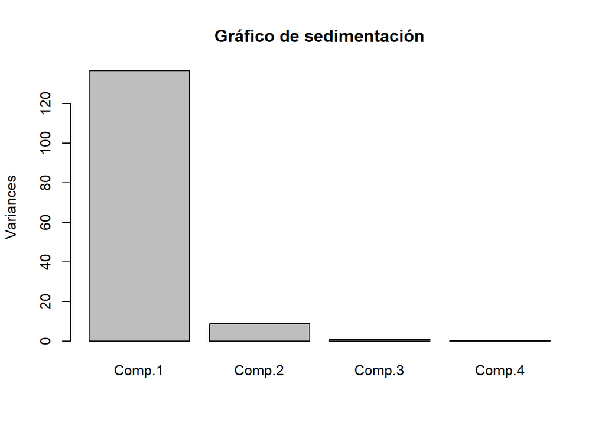

```r
screeplot(solacp,type="barplot",main="Gráfico de sedimentación")
```

Hay muchas otras pruebas más com la pruebas de Hipótesis de Anderson:
$$\left\{ \begin{array}{l}
H_0: \lambda_m=\ldots\lambda_p\\ H_1: \mbox{no todos
iguales}\end{array}\right.$$

# Adecuación de los datos al ACP

## Adecuación de los datos al ACP

$$KMO=\frac{\sum_j \sum_{i\not =j} r_{i j}^2}{\sum_j \sum_{i\not =j} r^2_{i j}+
\sum_j \sum_{i\not =j} a^2_{i j}}$$

donde $r_{i j}$ son los coef. de correlación entre las variables $i$ y $j$, mientras quelos $a_{i j}$ son los coef. de correlación parcial entre las variables $i$ y $j$ (equivalentes a las correlaciones entre los residuos de la regresiones de estas dos variables con las restantes).

- Niveles deKMO $\geq 0.5$ son considerados aceptables.

En nuestro ejemplo, las correlaciones parciales son:

```r
library(corpcor)
cor2pcor(cor(X))
```

```
##           [,1]       [,2]        [,3]        [,4]
## [1,] 1.0000000  0.9957943  0.90468746  0.31170534
## [2,] 0.9957943  1.0000000 -0.89188935 -0.31783572
## [3,] 0.9046875 -0.8918894  1.00000000  0.03389341
## [4,] 0.3117053 -0.3178357  0.03389341  1.00000000
```

En nuestro ejemplo el valor de KMO es (necesitamos crear una función que lo calcule):

```r
kmo.test <- function(df){
cor.sq = cor(df)^2
cor.sumsq = (sum(cor.sq)-dim(cor.sq)[1])
pcor.sq = cor2pcor(cor(df))^2
pcor.sumsq = (sum(pcor.sq)-dim(pcor.sq)[1])
kmo = cor.sumsq/(cor.sumsq+pcor.sumsq)
return(kmo)
}

kmo.test(X)
```

```
## [1] 0.4225498
```

El testde esfericidad de Barlett contrasta si la matriz de correlaciones es la identidad.

$$\left\{ \begin{array}{l}
H_0: \mbox{La matriz de correlaciones es la identidad}\\\\ H_1: \mbox{es
distinta de la
identidad}\end{array}\right.$$

Este test, al igual que casi todas las propiedades de los estimadores en ACP, requiere multinormalidad en la distribución de las variables.

En nuestro ejemplo:

```r
library(psych)
cortest.bartlett(cor(X),n=n)
```

```
## $chisq
## [1] 35.89478
##
## $p.value
## [1] 2.889513e-06
##
## $df
## [1] 6
```

El $p$-valor es muy pequeño por lo que no podemos aceptar la hipóstesi nula, la matriz de correlaciones es significativamente distinta de la identidad.

# Representaciones gráficas. Biplots

## Ejemplo

- En el mismo gráfico, se representan como vectores cada una de las variables iniciales~$\mathbf{X}$. Las coordenadas de dichas variables son las correlaciones de dichas variables con las componentes principales divididas por la raíz cuadrada del valor propio correspondiente a la componente principal.
- Sea $\tilde{\mathbf{X}}_i$ es una variable inicial. Calculemos la coordenadas de dicha variable inicial como vector de dos componentes representado en el biplot. Dichas coordenadas valen:
  $$\frac{\mbox{Cor}(\tilde{\mathbf{X}}_i,\mathbf{CP}_j)}{\sqrt{\lambda_j}},$$
  para $j=1,2$ que son los ejes correspondientes a las dos componentes principales.

## Ejemplo

- Vamos a realizar un biplot con los datos del ejemplo que hemos desarrollado en este capítulo. Se tendrá en cuenta el caso de ACP usando la matriz de covarianzas.
- Las coordenadas de las componentes principales de nuestros datos eran las siguientes:
  $$\mathbf{CP}=
  \left(
  \begin{array}{rrrr}
  -3.054 & 0.201 & -0.827 & 0.280 \\
  -12.719 & 2.480 & -0.333 & 0.103 \\
  -4.293 & -3.295 & -0.025 & -0.228 \\
  7.373 & -6.736 & -0.183 & 0.029 \\
  -15.299 & 0.565 & 1.029 & 0.183 \\
  -1.354 & 1.319 & 1.463 & -0.321 \\
  -6.997 & 1.411 & -1.460 & -0.233 \\
  13.677 & 0.437 & 0.629 & 0.282 \\
  22.666 & 3.618 & -0.292 & -0.095
  \end{array}
  \right).$$

## Ejemplo

- Para hallar las coordenadas de los vectores que representarán las variables, hemos de multiplicar cada vector propio por la raíz cuadrada de su valor propio correspondiente y por~$3$:

$$\mathbf{u}\cdot 3\cdot
\begin{pmatrix}
\sqrt{136.615}&0&0&0\\
0&\sqrt{8.861}&0&0\\
0&0&\sqrt{0.738}&0\\
0&0&0&\sqrt{0.0468}\\
\end{pmatrix}$$
$$=
\left(
\begin{array}{rrrr}
32.764 & -0.200 & 0.659 & 0.160 \\
11.904 & 3.163 & -1.704 & -0.368 \\
1.648 & -2.212 & 1.458 & -0.509 \\
3.409 & -8.051 & -1.086 & -0.009 \\
\end{array}
\right).$$

## Ejemplo

El código `biplot(solacp)` dibuja elbiplotde los dos primeros componentes.

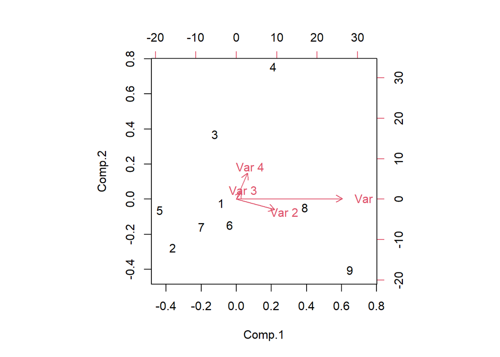

```r
biplot(solacp)
```

## Interpretación de un biplot

- La representación de las observaciones o los datos en un biplot equivale a proyectar las observaciones sobre el plano de las componentes principales estandarizadas para que tengan varianza unidad.
- La representación de variables mediante vectores de dos coordenadas cumple que la correlación entre dos variables iniciales $\mathbf{X}_i$ y $\mathbf{X}_j$ es aproximadamente el coseno del ángulo que forman en el biplot. Por tanto, si dos variables $\mathbf{X}_i$ y $\mathbf{X}_j$ están muy correlacionadas, el coseno será grande y el ángulo entre los vectores, pequeño. En caso contrario, si están poco correlacionadas, el coseno será pequeño y el ángulo entre los vectores estará próximo a un ángulo recto.

## Comunalidades.

En un ACP la comunalidad de la variable $X_j$ retenida por las $k$ primeras componentes es la proporción de varianza de la variable que queda explicada por esas componentes. Por ejemplo.

- Si retenemos sólo el componente $CP_1$ la comunalidad de la variable $X_j$ es:

$$h_j=r_{j 1}^2=\left( u_{1 j}\sqrt{\lambda_1}\right)^2$$
* Si retenemos los componentes$CP_1$ y $CP_2$ la comunalidad de la variable $X_j$ es:

$$h_j=r_{j 1}^2+r_{2 j}^2=\left( u_{1 j}\sqrt{\lambda_1}\right)^2+
\left( u_{2 j}\sqrt{\lambda_2}\right)^2$$

# Interpretación de las variables y los individuos

## Interpretación de las variables y los individuos

- Las variables también pueden representar de forma simultanea con los individuos en los componentes principales.
- Esta representación se hace mediante las coordenadas que la matriz de componentes %(cargasfactoriales) que nos explican las correlaciones de cada factor con cada variable.

En esta representación gráfica cada variable aparece como un punto de forma que :

- Cada variable está representada por el vector que une el origen de coordenadas cono el punto.
- Todosestán en círculo unidad (círculo de correlación).
- A medida que cada variable se acerca a la circunferencia unidad está mejor representado por los componentes retenidas y viceversa.
- El ángulo entre variables y componentes nos da una idea de su correlación, al nivel de retención de varianza total que tengamos.
- Así variable perpendiculares tenderán a ser *incorreladas*.
- Los valores de una variable crecen en la dirección de ésta.

# Y muchas cosas más..

## Y muchas cosas más..

Para acabar…

- El Análisis factorial confirmatorio se realiza sobre modelos establecidos de factores y se hacen inferencias sobre sus propiedades.
- El análisis factorial descriptivo ayuda a la descripción de los datos y a la búsqueda de factores.
- Regresión Lineal Múltiple
- Clasificación.
- Análisis de correspondencias simples y múltiples.
- … y muchas otras más